# 데이터 과학을 위한 R 알고리즘

역산법(Inverse Trasnfomation Sampling)

이광춘

[Tidyverse Korea](https://www.facebook.com/groups/tidyverse/)

2021-01-16

# 1 Inverse Transformation Method

역변환방법(Inverse Transformation Method)을 통한 표본 추출은 다음 3단계 방법을 거치게 된다.

1. 누적밀도함수(CDF)를 구한다.
2. 역변환을 취한다.
3. $U \sim \text{Unif} [0,1]$ 값을 역변환 인수로 넣는다.

상기 1, 2, 3 단계를 통해 해당 확률밀도함수(PDF)를 따르는 확률표본을 추출할 수 있다.

[video not shown]

# 2 역변환 방법 일반화

직관적으로 $U \sim \mathrm{Unif}[0,1]$ 균등분포에서 난수를 발생시켜 이를 누적밀도함수 $Y=F_X(X)$ 를 활용하여 $X$ 표본을 추출하는 것이다. 이를 일반화하여 역변환 방법을 설명하면 다음과 같다.

1. 누적밀도함수 $Y=F_X(X)$ 는 $\mathrm{Unif}[0,1]$$ 균등분포를 따르게 된다.
2. 이런 성질을 이용하여 역함수 $F_X^{-1}(Y) = X$가 되고
3. $U \sim \mathrm{Unif}[0,1]$을 대입시키게 되면 $F_X^{-1}(U)$로부터 $X$ 표본을 추출할 수 있다.

# 3 사례: 지수분포

지수분포(Exponential Distribution)를 따르는 난수를 추출해보자. 먼저, $\lambda$를 모수로 갖는 지수분포 확률밀도함수(Probability density function)를 다음과 같이 표현할 수 있다.

$$f(x;\lambda) = \begin{cases}
\lambda e^{-\lambda x} & x \ge 0, \\
0 & x < 0.
\end{cases}$$

지수분포에서 난수를 추출하는데 역변환방법을 사용해보자.

1. 누적밀도함수를 구한다. `u-치환` 방법을 사용하면 다음과 같이 누적밀도함수를 구할 수 있다.

$$F(x;\lambda) =
\begin{cases}
1-e^{-(\lambda x)} & x \ge 0, \\
0 & x < 0.
\end{cases}$$

2. 누적밀도함수의 역함수를 계산한다.

$$x = F^{-1}(y) = -\frac{1}{\lambda}\ln(1-y)$$

3. $U \sim \mathrm{Unif}(0,1)$ 균등분포에서 난수를 하나 잡아 $x_0 = F_X^{-1}(y_0) = -\frac{1}{\lambda}\ln(1-y_0)$ 에서 나온 $x_0$는 지수분포에서 나온 표본이 된다.

직관적인 그림을 통한 설명은 [Inverse transform sampling](https://en.wikipedia.org/wiki/Inverse_transform_sampling)을 참고한다.

# 4 R 코드

$\lambda = 3$ 을 모수로 갖는 지수분포에서 표본을 추출해보자. 먼저 균등분포에서 $[0, 1]$에서 표본을 추출하고 이를 앞서 수학적으로 찾은 $-\frac{1}{\lambda}\ln(1-y) = -\frac{1}{3}\ln(1-y)$ 함수에 넣는다.

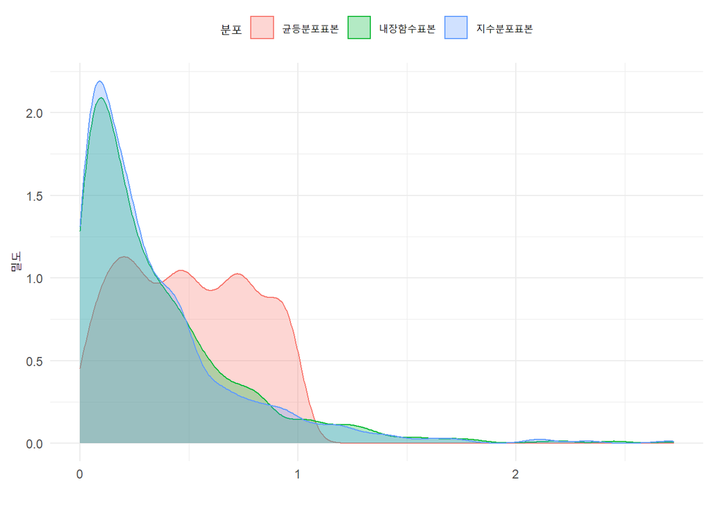

```r
library(tidyverse)

set.seed(1337)

unif_smpl <- runif(1000)
exp_smpl  <- -log(1-unif_smpl) / 3

inv_trans_tbl <- tibble(`균등분포표본` = unif_smpl,
                        `지수분포표본` = exp_smpl,
                        `내장함수표본` = rexp(1000, rate = 3))

inv_trans_tbl %>%
  pivot_longer(cols = everything(),
               names_to = "분포",
               values_to = "표본") %>%
  ggplot(aes(x = 표본, fill = 분포, color = 분포)) +
    geom_density(alpha = 0.3) +
    labs(x="", y="밀도") +
    theme_minimal() +
    theme(legend.position = "top")
```

함수로 만들어 표본수를 늘려 이론적인 지수분포에서 나온 표본값과 비교해보자.

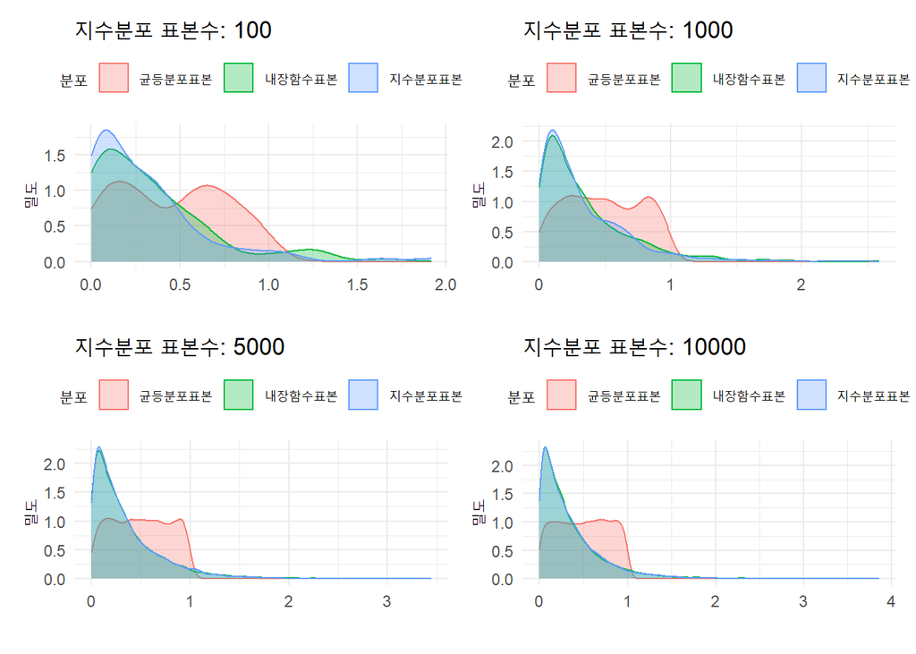

```r
library(patchwork)

draw_exp_smpl <- function(num_samples) {

  unif_smpl <- runif(num_samples)
  exp_smpl  <- -log(1-unif_smpl) / 3

  inv_trans_tbl <- tibble(`균등분포표본` = unif_smpl,
                          `지수분포표본` = exp_smpl,
                          `내장함수표본` = rexp(num_samples, rate = 3))

  inv_trans_tbl %>%
    pivot_longer(cols = everything(),
                 names_to = "분포",
                 values_to = "표본") %>%
    ggplot(aes(x = 표본, fill = 분포, color = 분포)) +
      geom_density(alpha = 0.3) +
      labs(x="", y="밀도", title = glue::glue("지수분포 표본수: {num_samples}")) +
      theme_minimal() +
      theme(legend.position = "top")
}

( draw_exp_smpl(100)   + draw_exp_smpl(1000) ) /
( draw_exp_smpl(5000)  + draw_exp_smpl(10000) )
```

데이터 과학자 [이광춘](https://github.com/statkclee/) 저작

*kwangchun.lee.7@gmail.com*